# MThambeliyagodage_Data605_W15_HW15

Matheesha Thambeliyagodage

May 15, 2018

### Problem 1

Find the equation of the regression line for the given points. Round any final values to the nearest hundredth, if necessary.

$(5.6, 8.8), (6.3, 12.4), (7, 14.8), (7.7, 18.2), (8.4, 20.8)$

#### SOLUTION 1

```r
x <- c(5.6, 6.3, 7, 7.7, 8.4)
y <- c(8.8, 12.4, 14.8, 18.2, 20.8)

r <- lm(y~x)
r
```

```
##
## Call:
## lm(formula = y ~ x)
##
## Coefficients:
## (Intercept)            x
##     -14.800        4.257
```

Based on the linear regression model, the regression line is $y = -14.8 + 4.257x$.

Check with plot.

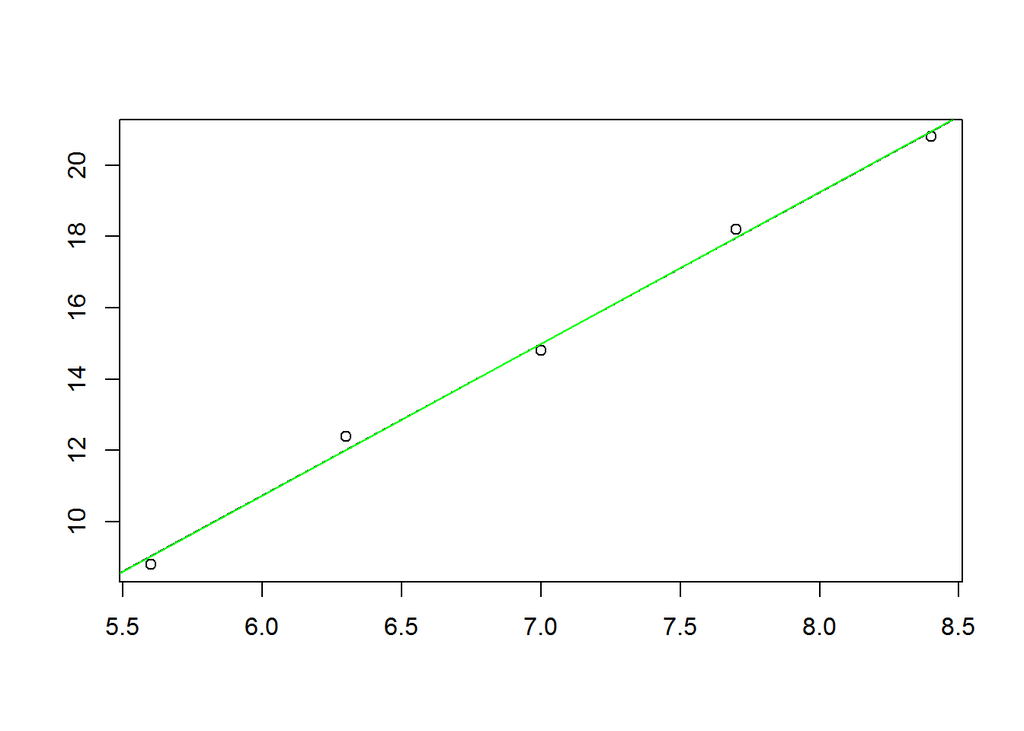

```r
plot(x,y, xlab="", ylab="")
abline(r)
lines(c(5,9), -14.8+4.257*c(5,9), col="green")
```

### Problem 2

Find all local maxima, local minima, and saddle points for the function given below. Write your answer(s) in the form $(x, y, z)$. Separate multiple points with a comma.

$f(x, y) = 24x - 6xy^2 - 8y^3$

#### SOLUTION 2

Partial derivatives:

$f_x(x, y) = 24 - 6y^2$

$f_y(x, y) = -12xy - 24y^2$

$f_x$ and $f_y$ are never underfined.

If $24-6y^2=0$, then $y^2 = 4$ and $y = \pm2$.

If $y=2$ and $-12xy - 24y^2=0$, then $-24x = 24\times 4$ and $x=-4$.

If $y=-2$ and $-12xy - 24y^2=0$, then $24x = 24\times 4$ and $x=4$.

Calculate $f(x, y)$.

$f(4,-2) = 24\times 4 - 6\times4\times (-2)^2 - 8 \times (-2)^3 = 64$

$f(-4,2) = 24\times (-4) - 6\times(-4)\times 2^2 - 8 \times 2^3 = -64$

**Two critical points**: $(4,-2,64)$ and $(-4, 2, -64)$.

Use Second Derivative test to determine if points are minimum, maximum or saddle.

Second partial derivatives:

$f_{xx}=0$

$f_{yy}=-12x-48y$

$f_{xy}=-12y$

Then $D(x,y) = f_{xx} f_{yy}-f^2_{xy} = -(-12y)^2 = -144y^2$.

$D(x,y)<0$ for all $(x, y)$, so per Second Derivative Test, any critical point is a saddle point.

### Problem 3

A grocery store sells two brands of a product, the “house” brand and a “name” brand. The manager estimates that if she sells the “house” brand for $x$ dollars and the “name” brand for $y$ dollars, she will be able to sell $81 - 21x + 17y$ units of the “house” brand and $40 + 11x - 23y$ units of the “name” brand.

Step 1. Find the revenue function $R ( x, y )$. Step 2. What is the revenue if she sells the “house” brand for $2.30 and the “name” brand for $4.10?

#### SOLUTION 3

$$\begin{split}
R(x,y) &= (81 - 21x + 17y)x + (40 + 11x - 23y)y \\
&= 81x-21x^2+17xy+40y+11xy-23y^2\\
&=81x+40y+28xy-21x^2-23y^2
\end{split}$$

$R(2.3, 4.1)=81\times 2.3+40\times 4.1+28\times 2.3\times 4.1-21\times (2.3)^2-23\times (4.1)^2 = 116.62$

### Problem 4

A company has a plant in Los Angeles and a plant in Denver. The firm is committed to produce a total of 96 units of a product each week. The total weekly cost is given by $C(x, y) = \frac{1}{6} x^2 + \frac{1}{6} y^2 + 7x + 25y + 700$, where $x$ is the number of units produced in Los Angeles and $y$ is the number of units produced in Denver. How many units should be produced in each plant to minimize the total weekly cost?

#### SOLUTION 4

Consider $x+y=96$, then $x=96-y$.

$$\begin{split}
C(x,y) = C(96-y,y) &= \frac{1}{6} x^2 + \frac{1}{6} y^2 + 7x + 25y + 700 \\
&=\frac{1}{6} (96-y)^2 + \frac{1}{6} y^2 + 7\times (96-y) + 25y + 700 \\
&=\frac{1}{6}(y^2 - 192 y + 9216) + \frac{1}{6}y^2+672-7y+25y+700\\
&= \frac{1}{6}y^2 - 32y+1536+\frac{1}{6}y^2+18y+1372\\
&= \frac{1}{3}y^2 - 14y + 2908\\
&=C_1(y)
\end{split}$$

$C_1'(y) = \frac{2}{3}y-14$

To find the minimal value consider $C_1'(y)=\frac{2}{3}y-14=0$, then $y=21$. Then $x=96-y=75$.

There should be 75 units produced in Los Angeles and 21 units produced in Denver.

### Problem 5

Evaluate the double integral on the given region.

$$\int\int_R (e^{8x+3y}) dA, R:2\le x\le4\ and\ 2 \le y \le 4$$

#### SOLUTION 5

$$\begin{split}
\int_2^4\int_2^4 (e^{8x+3y})\ dy\ dx &= \int_2^4 (\frac{1}{3}e^{8x+3y})|_2^4\ dx\\
&= \int_2^4 ((\frac{1}{3}e^{8x+12})-(\frac{1}{3}e^{8x+6}))\ dx\\
&= \int_2^4 \frac{1}{3}e^{8x+6}(e^6-1)\ dx\\
&= \frac{1}{24}e^{8x+6}(e^6-1) |_2^4\\
&= \frac{1}{24}e^{32+6}(e^6-1)-\frac{1}{24}e^{16+6}(e^6-1)\\
&= \frac{1}{24}(e^6-1)(e^{38}-e^{22})\\
&= \frac{1}{24}(e^{44} - e^{38} - e^{28} + e^{22})
\end{split}$$